# Tutoría junio

Jesús Martín

2025-06-17

Carga la dase de datos df_iam3_r:

```r
#setwd()
getwd ()
```

```
## [1] "C:/Users/jesus.martin/OneDrive - Madrid Digital/Docente/Introducción a la AP/Curso 2024_25/Bioestadística 1/Prácticas/Tutoría"
```

```r
df_iam3<-read.csv ("df_iam3_r.csv")
```

Recuerda que, en esta base se recogen una serie de características de 984 sujetos. En un momento en el tiempo se recogió qué sujetos habían tenido un evento tipo infarto de miocardio `iam`). Posteriormenete se siguió a los sujetos hasta otro punto en el tiempo. Tra ese punto t, sólo se recogió si el sujeto seguía fumando tras el primer infarto (`fum_p`) , la cifra de colesterol (`colesterol_p`) y la ocurrencia de un nuevo reinfarto (`iam2`)

Obten la variable edad (en años cumplidos), suponiendo que la fecha final de seguimiento es el 31/3/2025 a partir de la variable `fech_nac`

```r
#fech_nac viene definida como character, cambiamos a formato fecha
df_iam3$fech_nac <- as.Date(df_iam3$fech_nac)
fecha_fin <- as.Date("2025-03-31")
df_iam3$edad <- (fecha_fin-df_iam3$fech_nac)/365.25
df_iam3$edad <- as.numeric (round (df_iam3$edad,0))
```

## 1. Descriptivo

Extrae las edades medias y los percentiles 25, 50 y 75 de los pacientes con y sin iam

```r
library (psych)
by(df_iam3$edad, df_iam3$iam1, describe)
```

```
## df_iam3$iam1: No
##    vars   n  mean    sd median trimmed   mad min max range skew kurtosis   se
## X1    1 859 63.55 16.98     64   63.55 22.24  35  93    58    0    -1.23 0.58
## ------------------------------------------------------------
## df_iam3$iam1: Sí
##    vars   n  mean   sd median trimmed   mad min max range  skew kurtosis   se
## X1    1 125 63.78 17.4     65   63.82 23.72  35  93    58 -0.05    -1.36 1.56
```

```r
by(df_iam3$edad, df_iam3$iam1, function(x) quantile(x, probs = c(0.25, 0.5, 0.75), na.rm = TRUE))
```

```
## df_iam3$iam1: No
## 25% 50% 75%
##  49  64  79
## ------------------------------------------------------------
## df_iam3$iam1: Sí
## 25% 50% 75%
##  49  65  79
```

## 2. Evaluación normalidad

Evalúa la normalidad de la variable edad en ambos grupos

```r
# Shapiro-Wilk por grupo
by(df_iam3$edad, df_iam3$iam1, shapiro.test)
```

```
## df_iam3$iam1: No
##
##  Shapiro-Wilk normality test
##
## data:  dd[x, ]
## W = 0.95086, p-value = 2.536e-16
##
## ------------------------------------------------------------
## df_iam3$iam1: Sí
##
##  Shapiro-Wilk normality test
##
## data:  dd[x, ]
## W = 0.93888, p-value = 2.497e-05
```

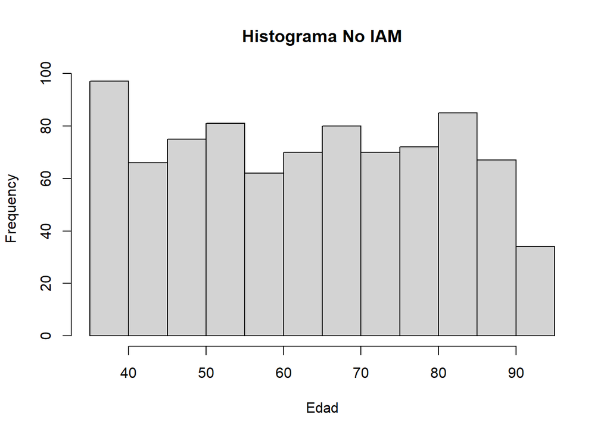

```r
#. Histogramas por grupo
hist(df_iam3$edad[df_iam3$iam1 == "No"], main = "Histograma No IAM", xlab = "Edad")
```

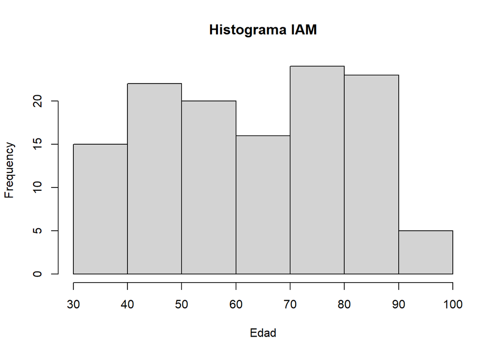

```r
hist(df_iam3$edad[df_iam3$iam1 == "Sí"], main = "Histograma IAM", xlab = "Edad")
```

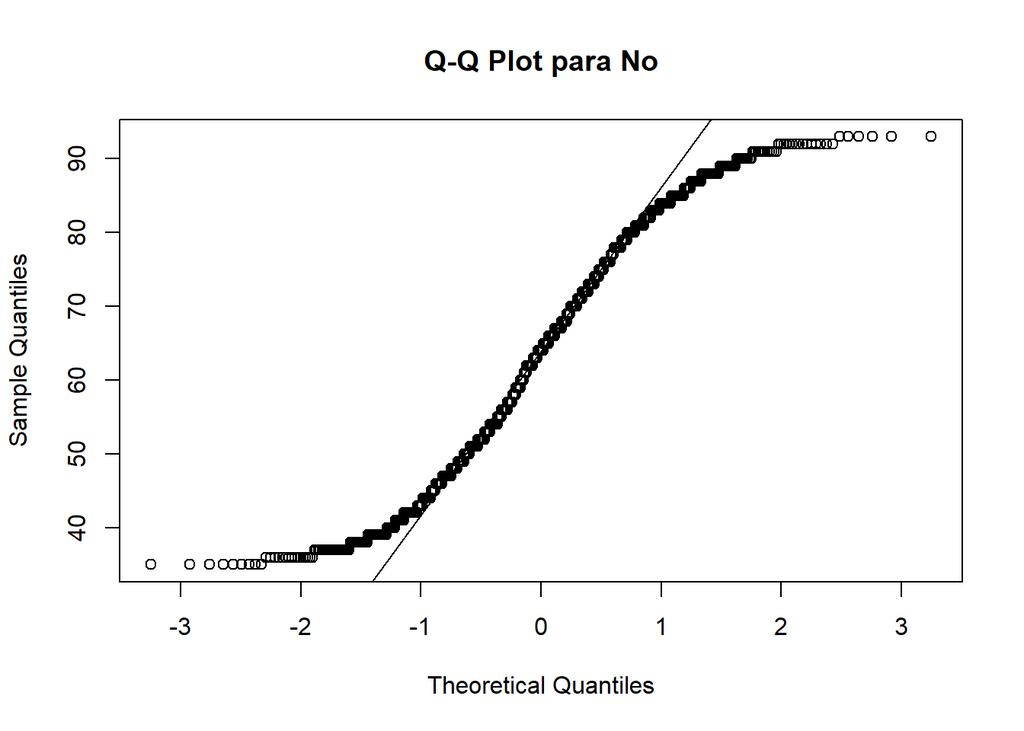

```r
#QQ Plot
qqnorm(df_iam3$edad[df_iam3$iam1 == "No"], main = "Q-Q Plot para No")
qqline(df_iam3$edad[df_iam3$iam1 == "No"])
```

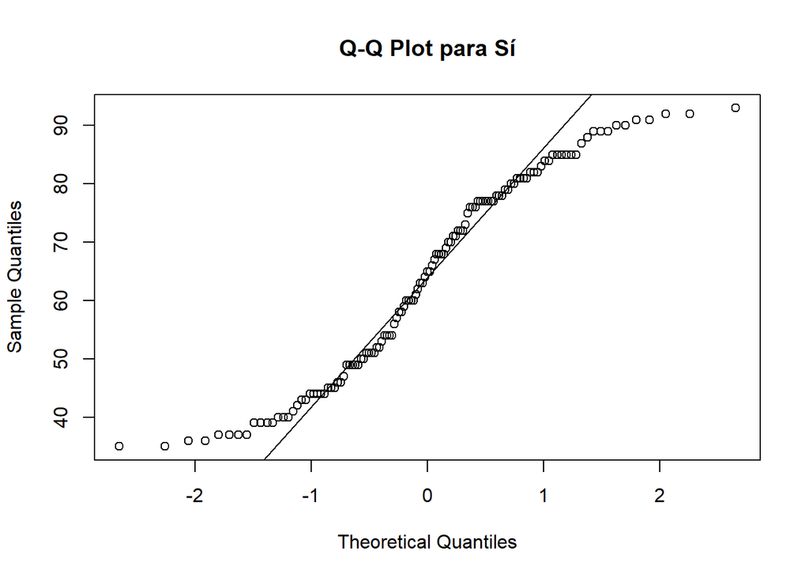

```r
qqnorm(df_iam3$edad[df_iam3$iam1 == "Sí"], main = "Q-Q Plot para Sí")
qqline(df_iam3$edad[df_iam3$iam1 == "Sí"])
```

## 3. Comparación de proporciones muestrales.

Compara las proporciones de varones en pacientes con el primer infarto. Comprueba que todas las frecuencias esperadas sean mayores que 5. Si alguna fuese inferior utiliza la corrección de Yates y el test exacto de Fisher. Interpreta los resultados

```r
# Para la variable fum
tabla_sex_iam1 <- table(df_iam3$sex, df_iam3$iam1)

(tabla_sex_iam1)
```

```
##
##          No  Sí
##   Mujer 435  63
##   Varón 424  62
```

```r
prop_sex_iam1 <- prop.table(tabla_sex_iam1, margin = 1)

prop_sex_iam1
```

```
##
##               No       Sí
##   Mujer 0.873494 0.126506
##   Varón 0.872428 0.127572
```

```r
chi_test_1 <- chisq.test(tabla_sex_iam1, correct = FALSE)

chi_test_1$expected
```

```
##
##               No      Sí
##   Mujer 434.7378 63.2622
##   Varón 424.2622 61.7378
```

```r
# Ver el resultado del test
chi_test_1
```

```
##
##  Pearson's Chi-squared test
##
## data:  tabla_sex_iam1
## X-squared = 0.0025204, df = 1, p-value = 0.96
```

El p-value es muy grande, no nos permite afirmar que las proporciones sean diferente de las esperadas por azar- Como no hay ninguna frecuencia esperada menor que 5, mantenemos el test sin corrección de Yates. Si quisiésemos aplicar esta corrección usaríamos la opción `correct=TRUE`.

Ahora vamos a aplicar un test exacto de Fisher para ver si hay diferencias en la proporción de hombres que sufren segundo infarto, respecto a los que no lo sufren.

```r
tabla_sex_iam2 <- table(df_iam3$sex, df_iam3$iam2)

tabla_sex_iam2
```

```
##
##          No  Sí
##   Mujer 475  23
##   Varón 459  27
```

```r
fisher_sex_iam2 <- fisher.test(tabla_sex_iam2)
fisher_sex_iam2
```

```
##
##  Fisher's Exact Test for Count Data
##
## data:  tabla_sex_iam2
## p-value = 0.5625
## alternative hypothesis: true odds ratio is not equal to 1
## 95 percent confidence interval:
##  0.6597884 2.2529615
## sample estimates:
## odds ratio
##   1.214591
```

La hipótesis nula en el test de Fisher es que la Odds Ratio es 1 y no puede descartarse en este caso.

## 4. Datos apareados, test de McNemar

Vamos a repetir el ejercicio de la práctica, comparar la proporción de fumadores inicial (`fum`) con la proporción de fumadores tras el primer infarto (`fum_p`), pero en el subgrupo que ha sufrido un segundo infarto (iam2=“Sí”)

```r
# Filtrar los datos donde iam2 == 1
subgrupo_iam2 <- df_iam3[df_iam3$iam2 == "Sí", ]

tabla_fum <- table(subgrupo_iam2$fum, subgrupo_iam2$fum_p)


tabla_fum
```

```
##
##      No Sí
##   No 21  0
##   Sí  9 20
```

```r
mcnemar_test <- mcnemar.test(tabla_fum)

mcnemar_test
```

```
##
##  McNemar's Chi-squared test with continuity correction
##
## data:  tabla_fum
## McNemar's chi-squared = 7.1111, df = 1, p-value = 0.007661
```

El p-value tan pequeño hace poco probable que las dos proporciones sean iguales.

Si lo hiciésemos sin corrección de Yates…

```r
mcnemar_test <- mcnemar.test(tabla_fum, correct=FALSE)

mcnemar_test
```

[output not shown]

El resultado no es muy diferente del anterior

## 5. Diferencia de proporciones

Vamos a estudiar las diferencias de proporciones de fumadores tras el primer infarto (`fum_p`)

```r
tabla_fum_p_iam2 <- table(df_iam3$fum_p, df_iam3$iam2)

tabla_fum_p_iam2
```

```
##
##       No  Sí
##   No 777  30
##   Sí 157  20
```

```r
dif_prop <- prop.test(tabla_fum_p_iam2)


dif_prop
```

```
##
##  2-sample test for equality of proportions with continuity correction
##
## data:  tabla_fum_p_iam2
## X-squared = 15.765, df = 1, p-value = 7.17e-05
## alternative hypothesis: two.sided
## 95 percent confidence interval:
##  0.02394365 0.12769561
## sample estimates:
##    prop 1    prop 2
## 0.9628253 0.8870056
```

## 6. Diferencia de medias dos grupos

Vamos a comparar los niveles de colesterol en aquellos sujetos que tuvieron infarto y los que no

Lo primero será valorar los supuestos de normalidad y homogeneidad de la varianza en ambos grupos

```r
# Filtrar los datos por grupo
col_infarto <- df_iam3$colesterol[df_iam3$iam1 == "Sí"]
col_no_infarto <- df_iam3$colesterol[df_iam3$iam1 == "No"]

# Prueba de normalidad (Shapiro-Wilk) para el grupo con infarto
shapiro.test(col_infarto)
```

```
##
##  Shapiro-Wilk normality test
##
## data:  col_infarto
## W = 0.93274, p-value = 9.741e-06
```

```r
# Prueba de normalidad (Shapiro-Wilk) para el grupo sin infarto
shapiro.test(col_no_infarto)
```

```
##
##  Shapiro-Wilk normality test
##
## data:  col_no_infarto
## W = 0.93298, p-value < 2.2e-16
```

```r
#Otra forma de hacerlo
by(df_iam3$colesterol, df_iam3$iam1, shapiro.test)
```

```
## df_iam3$iam1: No
##
##  Shapiro-Wilk normality test
##
## data:  dd[x, ]
## W = 0.93298, p-value < 2.2e-16
##
## ------------------------------------------------------------
## df_iam3$iam1: Sí
##
##  Shapiro-Wilk normality test
##
## data:  dd[x, ]
## W = 0.93274, p-value = 9.741e-06
```

No son normales, Comprobar con métodos gráficos

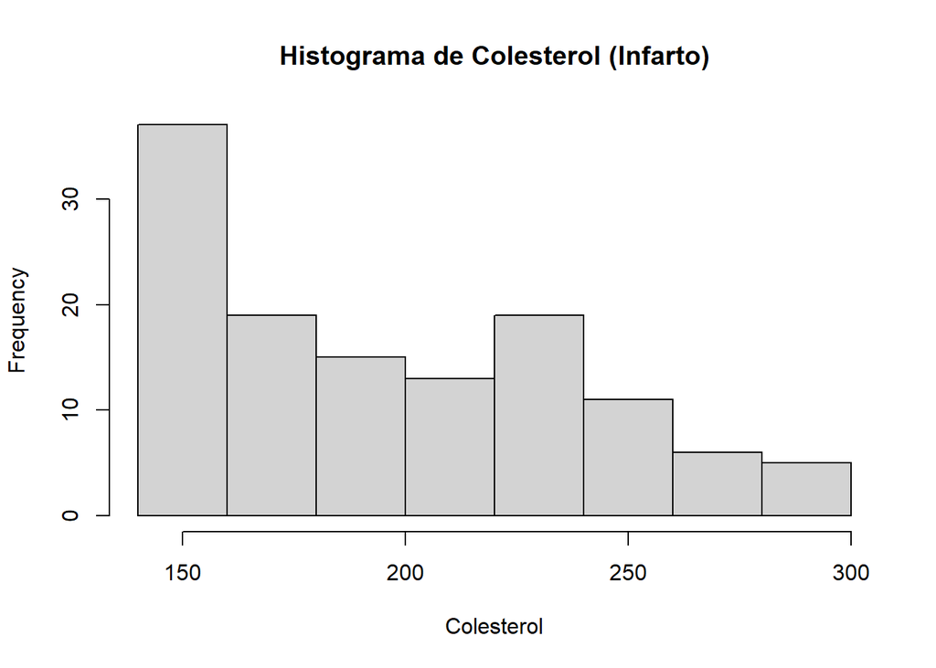

```r
# Histograma y gráfico Q-Q para el grupo con infarto
hist(col_infarto,
     main = "Histograma de Colesterol (Infarto)",
     xlab = "Colesterol")
```

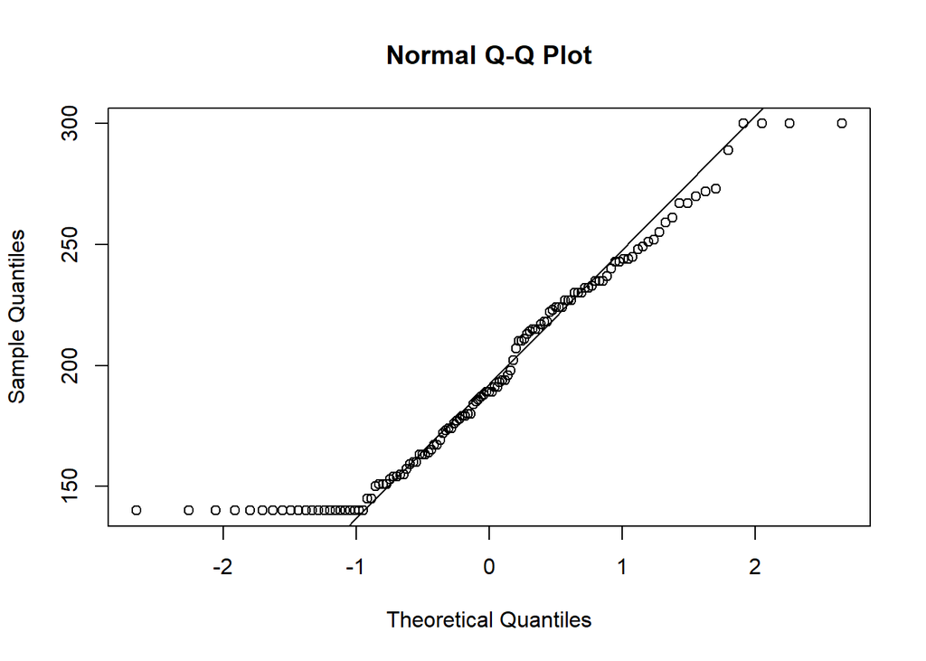

```r
qqnorm(col_infarto)
qqline(col_infarto)
```

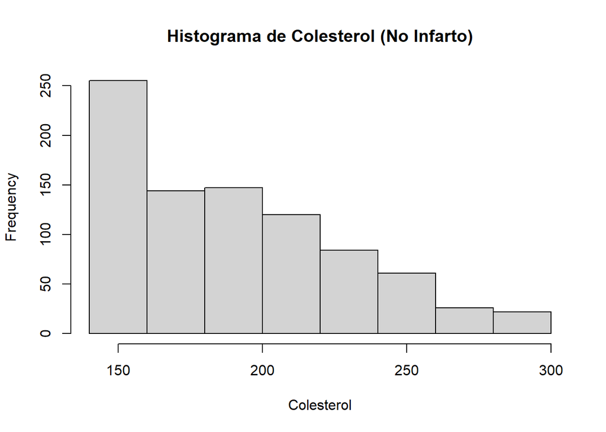

```r
# Histograma y gráfico Q-Q para el grupo sin infarto
hist(col_no_infarto,
     main = "Histograma de Colesterol (No Infarto)",
     xlab = "Colesterol")
```

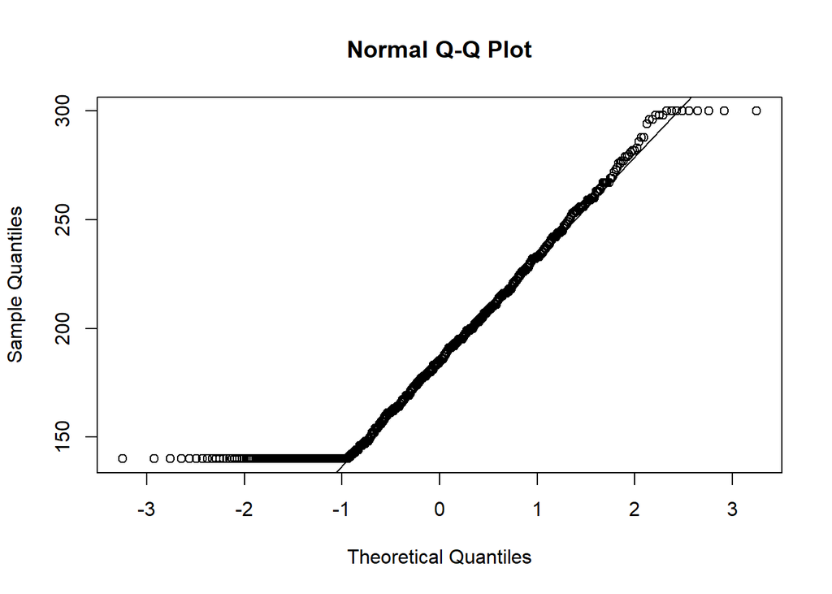

```r
qqnorm(col_no_infarto)
qqline(col_no_infarto)
```

No parecen normales en cualquier caso

Ahora vamos a testar la hipótesis de igualdad de las varianzas.

El test de Levene está implementado en el paquete `car` , y precisa que la variable que divide la muestra sea una variable factor

```r
#install.packages("car")
library(car)
df_iam3$iam1 <- as.factor(df_iam3$iam1)

levene_result <- leveneTest(colesterol ~ iam1, data = df_iam3)
levene_result
```

```
## Levene's Test for Homogeneity of Variance (center = median)
##        Df F value  Pr(>F)
## group   1  3.6621 0.05595 .
##       982
## ---
## Signif. codes:  0 '***' 0.001 '**' 0.01 '*' 0.05 '.' 0.1 ' ' 1
```

Otra opción para comprobar homogeneidad de varianzas en R base , sería la prueba F de homogeneidad de varianzas también conocida prueba F de Snedecor.

```r
# Prueba F para comparar las varianzas entre hombres y mujeres
var_test <- var.test(colesterol ~ iam1, data = df_iam3)

# Mostrar resultados
print(var_test)
```

```
##
##  F test to compare two variances
##
## data:  colesterol by iam1
## F = 0.8289, num df = 858, denom df = 124, p-value = 0.148
## alternative hypothesis: true ratio of variances is not equal to 1
## 95 percent confidence interval:
##  0.6259846 1.0683710
## sample estimates:
## ratio of variances
##          0.8289013
```

```r
t_test_result <- t.test(colesterol ~ iam1, data = df_iam3, var.equal = F)
t_test_result
```

```
##
##  Welch Two Sample t-test
##
## data:  colesterol by iam1
## t = -1.4988, df = 155.39, p-value = 0.136
## alternative hypothesis: true difference in means between group No and group Sí is not equal to 0
## 95 percent confidence interval:
##  -14.749676   2.023268
## sample estimates:
## mean in group No mean in group Sí
##         189.3248         195.6880
```

## 7. Comparación de medias para datos apareados

Vamos a realizar una prueba T de Student para datos apareados comparando el colesterol medido antes y después del punto t (cuando se evidenció si habia habido o no un infarto, `colesterol` y `colesterol_p)`

```r
#Evaluamos normalidad de las distribución de las diferencias

diferencias <- df_iam3$colesterol - df_iam3$colesterol_p

# Test de normalidad (Shapiro-Wilk)
shapiro.test(diferencias)
```

```
##
##  Shapiro-Wilk normality test
##
## data:  diferencias
## W = 0.74283, p-value < 2.2e-16
```

Las distribuciones no son normales , pero sabemos que cuando la n es suficientemente grande, la t de student admite desviaciones de la normalidad , por lo que nos permitimos utilizar la t de student para datos apareados

```r
t.test(df_iam3$colesterol, df_iam3$colesterol_p, paired = TRUE)
```

```
##
##  Paired t-test
##
## data:  df_iam3$colesterol and df_iam3$colesterol_p
## t = 7.1395, df = 983, p-value = 1.819e-12
## alternative hypothesis: true mean difference is not equal to 0
## 95 percent confidence interval:
##  1.808424 3.179381
## sample estimates:
## mean difference
##        2.493902
```

Nos dice que el valor de la p es muy pequeño ( 1.819e-12), pero además nos ofrece cuál es la diferencia de medias y su IC del 95% (2.493902, IC95%: 1.808424 a 3.179381 mg/dl, colesterol es mayor que qcolesterol_p), que nos ofrece una perspectiva más útil para la toma de decisiones.

## 8. Comparación de medias varios grupos

Se pretende comparar las cifras de colesterol por clase social. Para ello usaremos un ANOVA de una vía.

Primero evaluaremos visualmente las diferencias

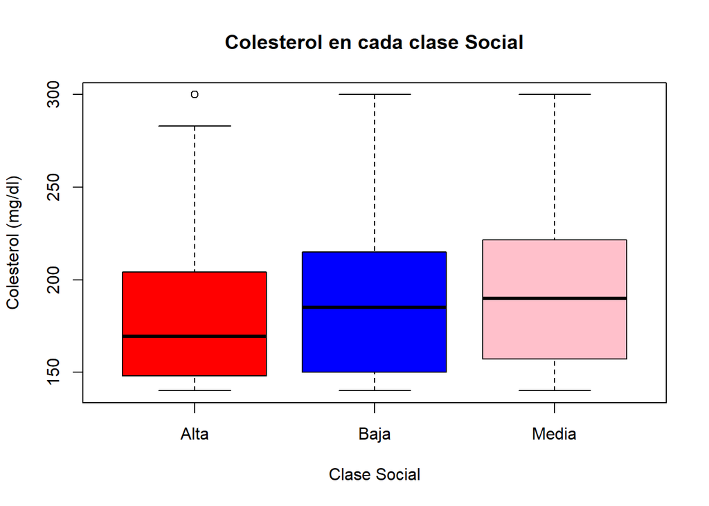

```r
boxplot(colesterol ~ clas_soc, data = df_iam3,
        main = "Colesterol en cada clase Social",
        xlab = "Clase Social",
        ylab = "Colesterol (mg/dl)",
        col = c("red", "blue", "pink"),  # Colores para las cajas
        border = "black")  # Color del borde
```

Parece que la clase “Alta” tiene valores más bajos de colesterol, vamos a estudiarlo formalmente con una ANOVA. Se puede hacer directamente con el paquete base `Stats` o con la librería `cars`

```r
# Debemos asegurarnos de que la variable clas_soc es un factor()
df_iam3$clas_soc<- as.factor(df_iam3$clas_soc)

test_anova<-aov(colesterol~clas_soc,data=df_iam3)
anova(test_anova)
```

```
## Analysis of Variance Table
##
## Response: colesterol
##            Df  Sum Sq Mean Sq F value  Pr(>F)
## clas_soc    2    8440  4219.8  2.4711 0.08502 .
## Residuals 981 1675216  1707.7
## ---
## Signif. codes:  0 '***' 0.001 '**' 0.01 '*' 0.05 '.' 0.1 ' ' 1
```

Con el paquete `cars`

```r
library(car)

# Crear el modelo lineal
test_anova2 <- lm(colesterol ~ clas_soc, data = df_iam3)

# Realizar el ANOVA
anova(test_anova2)
```

```
## Analysis of Variance Table
##
## Response: colesterol
##            Df  Sum Sq Mean Sq F value  Pr(>F)
## clas_soc    2    8440  4219.8  2.4711 0.08502 .
## Residuals 981 1675216  1707.7
## ---
## Signif. codes:  0 '***' 0.001 '**' 0.01 '*' 0.05 '.' 0.1 ' ' 1
```

Comprobación de supuestos de normalidad y homogeneidad de la varianza

Para verificar la normalidad, usaremos Shapiro-Wilk y para las varianzas la prueba de Levene del paquete `car`

```r
shapiro_results <- by(df_iam3$colesterol, df_iam3$clas_soc, shapiro.test)

shapiro_results
```

```
## df_iam3$clas_soc: Alta
##
##  Shapiro-Wilk normality test
##
## data:  dd[x, ]
## W = 0.90741, p-value = 5.854e-06
##
## ------------------------------------------------------------
## df_iam3$clas_soc: Baja
##
##  Shapiro-Wilk normality test
##
## data:  dd[x, ]
## W = 0.9223, p-value = 9.967e-14
##
## ------------------------------------------------------------
## df_iam3$clas_soc: Media
##
##  Shapiro-Wilk normality test
##
## data:  dd[x, ]
## W = 0.94419, p-value = 1.854e-12
```

No son normales pero el ANOVA con grupos grandes resiste bien violaciones de la normalidad

Ahora recurriremos al paquete `car` para hacer la prueba de Levene

```r
library(car)
leveneTest(colesterol ~ clas_soc, data = df_iam3)
```

```
## Levene's Test for Homogeneity of Variance (center = median)
##        Df F value Pr(>F)
## group   2  0.7086 0.4926
##       981
```

El supuesto de homogeneidad de la varianza se cumple

Otra forma de valorar los supuestos de aplicación de la prueba es mediante el análisis de residuales. Por ejemplo haciendo un Q-Q-plot. Esto solo puede hacerse tras generar el modelo

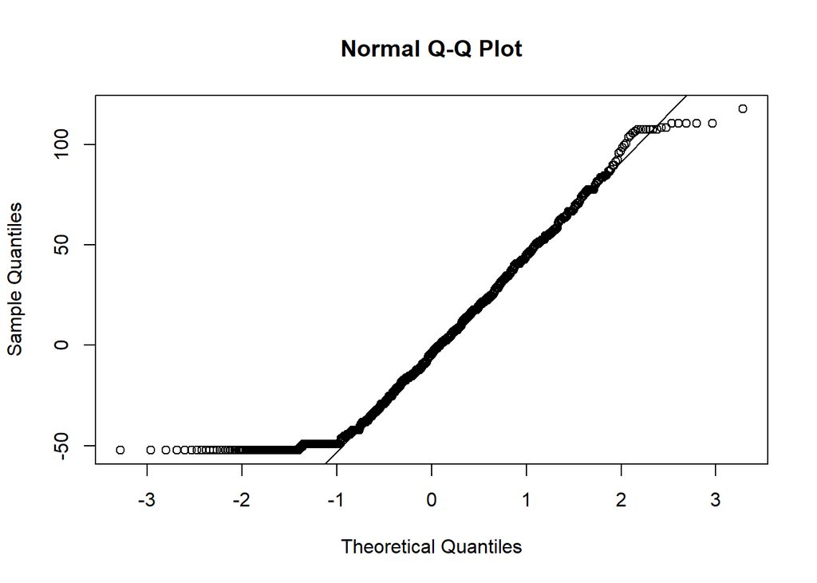

```r
qqnorm(residuals(test_anova))
qqline(residuals(test_anova))
```

Vamos a valorar si hay diferencias entre grupos con las correcciones de Bonferroni y Tukey, Primero usaremos la función `pairwise.t.test`

```r
resultado <- pairwise.t.test(df_iam3$colesterol,
    df_iam3$clas_soc, p.adjust.method = "bonferroni")
resultado
```

```
##
##  Pairwise comparisons using t tests with pooled SD
##
## data:  df_iam3$colesterol and df_iam3$clas_soc
##
##       Alta  Baja
## Baja  0.389 -
## Media 0.091 0.868
##
## P value adjustment method: bonferroni
```

Usaremos la función `TukeyHSD` siempre que previamente usemos la función `aov`

```r
anova_result <- aov(colesterol ~ clas_soc, data = df_iam3)
tukey_result <- TukeyHSD(anova_result)

tukey_result
```

```
##   Tukey multiple comparisons of means
##     95% family-wise confidence level
##
## Fit: aov(formula = colesterol ~ clas_soc, data = df_iam3)
##
## $clas_soc
##                 diff        lwr       upr     p adj
## Baja-Alta   7.167722 -3.9246227 18.260066 0.2834322
## Media-Alta 10.114317 -0.8261364 21.054771 0.0768977
## Media-Baja  2.946596 -3.5763897  9.469581 0.5390186
```

Para la comparación formal post-hoc para varianzas no homogéneas tenemos el test de Tamhane, que necesita del paquete `PMCMRplus`

```r
#install.packages("PMCMRplus")
library(PMCMRplus)
df_iam3$clas_soc<- as.factor(df_iam3$clas_soc)

anova <- aov(colesterol ~ clas_soc, data = df_iam3)

# Aplicar el test de Tamhane T2
summary(T2b <- tamhaneT2Test(anova, welch = FALSE))
```

```
##
##  Pairwise comparisons using Tamhane's T2'-test for unequal variances
```

```
## data: colesterol by clas_soc
```

```
## alternative hypothesis: two.sided
```

```
## P value adjustment method: T2' (Sidak)
```

```
## H0
```

```
##                   t value Pr(>|t|)
## Baja - Alta == 0    1.592 0.299782
## Media - Alta == 0   2.300 0.064017 .
## Media - Baja == 0   1.050 0.648068
```

```
## Signif. codes: 0 '***' 0.001 '**' 0.01 '*' 0.05 '.' 0.1 ' ' 1
```